# JUDGE channel — VI. Asymmetry under Tversky’s contrast model

What kind of thing is B[i,j] ≠ B[j,i]? A features-of-similarity reading, and what it says we should collect next

ecb

2026-07-28

## Frame

Report II asked the *measurement* question about `B[i,j] ≠ B[j,i]` — how much, is it reliable, do we symmetrize — and answered it: ~21% of the centered signal, ≈half a removable “prevalence gradient”, the residual curl “real but faint and idiosyncratic”, so symmetrize and keep direction as a flagged side channel. That verdict stands for the similarity measurement. But it left the asymmetry *theoretically unclaimed*: a marginal to strip and a residual we didn’t model.

This report reads the same object through **Tversky (1977), “Features of similarity.”** That is not decoration. Tversky’s is the canonical account of *judged* similarity as non-metric — asymmetric, context-dependent, and generated by a feature-matching process rather than a distance — and it makes **quantitative, falsifiable predictions about the exact decomposition Report II computed**. It is also already the psychological grounding the readout paper leans on for representation-vs-judgment divergence, so it is worth knowing whether JUDGE actually behaves the way Tversky says judged similarity behaves.

**The contrast model.** For objects *a*, *b* with feature sets *A*, *B* and a non-negative salience measure *f*,

$$s(a,b) \;=\; \theta\, f(A \cap B) \;-\; \alpha\, f(A - B) \;-\; \beta\, f(B - A),
\qquad \theta,\alpha,\beta \ge 0 .$$

The judgment is **directed**: *a* is the **subject**, *b* the **referent**, and the subject’s distinctive features are weighted more heavily (α > β). JUDGE’s prompt fixes the roles unambiguously —

> *Consider a person who is very **{i}**. How likely is this person to also be **{j}**?*

— so **i is the subject and j the referent**, and `B[i,j]` is a contrast-model similarity in Tversky’s sense. Two consequences drive everything below.

**Prediction 1 (separability).** If *f* is additive over the shared/distinctive split — `f(A) = f(A∩B) + f(A−B)` — then

$$B[i,j] - B[j,i] \;=\; (\beta-\alpha)\,\bigl(f_i - f_j\bigr),$$

which is a **pure gradient**: the antisymmetric part is *exactly* the difference of a single per-adjective potential, with **zero curl**. So Report II’s Helmholtz–Hodge split is not an arbitrary chart — the gradient share *is* the contrast model’s fit, and the curl is precisely the variance the additive contrast model cannot produce.

**Prediction 2 (direction).** Since α > β, `s(a,b) > s(b,a)` iff `f(B) > f(A)`: the **less prominent object makes the better subject**. Tversky’s examples are “North Korea is more similar to China than China is to North Korea” and “the variant is more similar to the prototype than the prototype to the variant.” Here that means specific/rare traits should imply general/prominent ones far more than the reverse.

**Prediction 3 (diagnosticity).** *f* is not context-free: the weight a feature carries depends on what it classifies in the current stimulus set. Non-additivity of *f* is the mechanism, and it is the only thing in the theory that can generate curl. So under this reading the curl is not leftover noise — it is **where the diagnosticity effect lives**, and it should be *structured*, not random.

```r
sym  <- fread_gz("sym_ev.csv.gz")
asy  <- fread_gz("asym_ev.csv.gz")
dir  <- fread_gz("dir_ev.csv.gz")
marg <- read_csv_("marginals.csv") %>% as_tibble()
n    <- nrow(adjectives)
disc <- setdiff(MODELS, c("Llama", "FalconMamba"))   # 10 discriminating raters

Dl <- lapply(MODELS, function(m) { D <- build_matrix(asy, m, "asym"); D[is.na(D)] <- 0; D })
Sl <- lapply(MODELS, function(m) build_matrix(sym, m, "sym"))
names(Dl) <- names(Sl) <- MODELS
Gm <- sapply(MODELS, function(m) rowMeans(Dl[[m]]))          # potentials, 523 x 12
Cl <- lapply(MODELS, function(m) Dl[[m]] - outer(Gm[,m], Gm[,m], "-"))  # curl
names(Cl) <- MODELS

Dbar <- Reduce(`+`, Dl[disc]) / length(disc)
Cbar <- Reduce(`+`, Cl[disc]) / length(disc)
Sbar <- Reduce(`+`, Sl[disc]) / length(disc)
Bbar <- Reduce(`+`, lapply(disc, function(m) build_matrix(dir, m, "dir"))) / length(disc)
gbar <- rowMeans(Gm[, disc])
fbar <- -gbar                                                # prominence: high f = strong referent
```

## 1. How much of the asymmetry is the contrast model? (about half)

```r
sep <- sapply(MODELS, function(m) sum(outer(Gm[,m], Gm[,m], "-")^2) / sum(Dl[[m]]^2))
knitr::kable(
  tibble(Model = DISPLAY[MODELS], Family = FAMILY[MODELS],
         `Separable (contrast-model) share of asymmetry` = round(100*sep, 1)) %>%
    arrange(desc(`Separable (contrast-model) share of asymmetry`)),
  caption = "Share of each rater's antisymmetric variance that an additive-f contrast model can produce.")
```

Share of each rater’s antisymmetric variance that an additive-f contrast model can produce.

| Model | Family | Separable (contrast-model) share of asymmetry |
| --- | --- | --- |
| Phi4-mini-3.8B | Phi | 63.7 |
| Llama3.2-3B | Llama | 61.5 |
| Llama3.1-8B | Llama | 56.9 |
| FalconMamba-7B | Falcon | 54.3 |
| Qwen2.5-32B | Qwen | 52.8 |
| Qwen2.5-3B | Qwen | 52.0 |
| Qwen2.5-7B | Qwen | 50.0 |
| Gemma3-4B | Gemma | 48.5 |
| Gemma3-27B | Gemma | 46.3 |
| Aya-expanse-8B | Aya | 41.8 |
| Gemma3-12B | Gemma | 41.1 |
| Gemma-4-31B | Gemma | 35.8 |

```r
cat(sprintf("mean %.1f%%   |   consensus (10-rater mean matrix) %.1f%%\n",
            100*mean(sep),
            100*sum(outer(gbar,gbar,"-")^2)/sum(Dbar^2)))
```

```
## mean 50.4%   |   consensus (10-rater mean matrix) 57.3%
```

**Mean 50%, consensus 57%.** Half of the directional signal is exactly the shape Prediction 1 requires, and the half that isn’t is the theory’s own residual category (Prediction 3). Note that this is a *substantive model fit*, not a coordinate choice: “one number per adjective explains half the 273,006-cell directional matrix” is a strong constraint that a matrix of directional idiosyncrasies had no obligation to satisfy.

## 2. The recovered prominence scale, and Prediction 2

The least-squares potential `g[i] = mean_j (B[i,j] − B[j,i])` estimates `(β−α)(f_i − f̄)`. Since α > β the coefficient is negative, so **f ∝ −g**: adjectives with the most negative `g` are the most prominent (best referents), those with the most positive `g` the least.

```r
mg <- marg %>% filter(model %in% disc) %>% group_by(idx) %>%
  summarise(prev = mean(col_mean), gen = mean(row_mean), .groups = "drop") %>% arrange(idx)
Rcons <- profile_cor(Sbar); ee <- eigen(Rcons, symmetric = TRUE)
halo <- ee$vectors[,1] * sqrt(max(ee$values[1], 0))
if (halo[match("good", ADJ)] < 0) halo <- -halo          # orient: + = desirable
P <- tibble(adjective = ADJ, f = fbar, prev = mg$prev, halo = halo,
            breadth = rowMeans(Sbar, na.rm = TRUE))

bind_rows(
  P %>% arrange(desc(f)) %>% slice(1:10) %>% mutate(end = "most prominent (best referents)"),
  P %>% arrange(f)       %>% slice(1:10) %>% mutate(end = "least prominent (best subjects)")) %>%
  transmute(End = end, Adjective = adjective, f = round(f,2),
            `base rate (col mean)` = round(prev,2), `halo (valence)` = round(halo,2)) %>%
  knitr::kable(caption = "The two ends of the recovered prominence scale f = -g.")
```

The two ends of the recovered prominence scale f = -g.

| End | Adjective | f | base rate (col mean) | halo (valence) |
| --- | --- | --- | --- | --- |
| most prominent (best referents) | thinking | 1.87 | 6.34 | 0.79 |
| most prominent (best referents) | awake | 1.75 | 5.97 | 0.76 |
| most prominent (best referents) | exhausted | 1.23 | 4.84 | -0.44 |
| most prominent (best referents) | disappointed | 1.16 | 4.94 | -0.44 |
| most prominent (best referents) | uncomfortable | 1.13 | 4.77 | -0.56 |
| most prominent (best referents) | frustrated | 1.07 | 4.89 | -0.66 |
| most prominent (best referents) | tired | 1.05 | 4.61 | -0.37 |
| most prominent (best referents) | annoyed | 0.96 | 4.57 | -0.68 |
| most prominent (best referents) | irritated | 0.93 | 4.51 | -0.73 |
| most prominent (best referents) | normal | 0.93 | 5.12 | 0.78 |
| least prominent (best subjects) | blind | -2.58 | 1.64 | 0.74 |
| least prominent (best subjects) | tiny | -2.00 | 2.08 | 0.52 |
| least prominent (best subjects) | retarded | -1.73 | 1.53 | -0.39 |
| least prominent (best subjects) | artificial | -1.70 | 2.40 | -0.45 |
| least prominent (best subjects) | handicapped | -1.61 | 2.64 | 0.36 |
| least prominent (best subjects) | disabled | -1.37 | 2.96 | 0.42 |
| least prominent (best subjects) | dumb | -1.25 | 2.41 | -0.70 |
| least prominent (best subjects) | senile | -1.23 | 2.28 | -0.63 |
| least prominent (best subjects) | short | -1.22 | 2.57 | 0.71 |
| least prominent (best subjects) | crazy | -1.18 | 2.80 | -0.68 |

```r
pair_row <- function(a, b) {
  ia <- match(a, ADJ); ib <- match(b, ADJ)
  tibble(`subject ⇒ referent` = paste(a, "⇒", b), fwd = Bbar[ia, ib],
         `reverse` = Bbar[ib, ia], `Δ` = Bbar[ia, ib] - Bbar[ib, ia],
         `f(subj)` = fbar[ia], `f(ref)` = fbar[ib])
}
bind_rows(pair_row("blind","thinking"), pair_row("retarded","awake"),
          pair_row("senile","tired"),   pair_row("famous","normal"),
          pair_row("handicapped","emotional"), pair_row("tiny","uncomfortable")) %>%
  mutate(across(where(is.numeric), ~round(.,2))) %>%
  knitr::kable(caption = "Prediction 2: the low-prominence member is the better subject. Cohort consensus, 1-7 Likert.")
```

Prediction 2: the low-prominence member is the better subject. Cohort consensus, 1-7 Likert.

| subject ⇒ referent | fwd | reverse | Δ | f(subj) | f(ref) |
| --- | --- | --- | --- | --- | --- |
| blind ⇒ thinking | 6.96 | 1.91 | 5.06 | -2.58 | 1.87 |
| retarded ⇒ awake | 5.40 | 1.35 | 4.05 | -1.73 | 1.75 |
| senile ⇒ tired | 5.91 | 1.61 | 4.31 | -1.23 | 1.05 |
| famous ⇒ normal | 4.27 | 1.61 | 2.66 | -1.18 | 0.93 |
| handicapped ⇒ emotional | 5.96 | 3.02 | 2.94 | -1.61 | 0.87 |
| tiny ⇒ uncomfortable | 5.11 | 1.98 | 3.12 | -2.00 | 1.13 |

```r
ut   <- upper.tri(Dbar)
pred <- outer(fbar, fbar, function(a, b) sign(b - a))[ut]
gp   <- abs(outer(fbar, fbar, "-"))[ut]
agree <- sign(Dbar[ut]) == pred
tibble(`Pairs considered` = c("all pairs", "prominence gap above median",
                              "prominence gap in the top decile"),
       n = c(sum(ut), sum(gp > median(gp)), sum(gp > quantile(gp, .9))),
       `% asymmetric in the predicted direction` =
         round(100*c(mean(agree), mean(agree[gp > median(gp)]),
                     mean(agree[gp > quantile(gp, .9)])), 1)) %>%
  knitr::kable(caption = "Sign agreement with Prediction 2, by how far apart the two adjectives are in prominence.")
```

Sign agreement with Prediction 2, by how far apart the two adjectives are in prominence.

| Pairs considered | n | % asymmetric in the predicted direction |
| --- | --- | --- |
| all pairs | 136503 | 75.9 |
| prominence gap above median | 68251 | 88.3 |
| prominence gap in the top decile | 13651 | 96.7 |

## 3. Is *f* a feature measure, or just a base rate?

The obvious deflationary rival: JUDGE asks a conditional-probability question, so `B[i,j] ≈ P(j | i)`, and `P(j|i) − P(i|j)` is monotone in the base-rate difference for any symmetric association. On that account *f* is nothing but prevalence and Tversky adds no content. The base rate is indeed the single biggest correlate — but it is **not the whole story**, and the deviation is lawful.

```r
knitr::kable(round(cor(P %>% select(f, prev, halo, breadth), use = "pairwise"), 2),
             caption = "Correlates of the recovered prominence scale.")
```

Correlates of the recovered prominence scale.

|  | f | prev | halo | breadth |
| --- | --- | --- | --- | --- |
| f | 1.00 | 0.84 | 0.08 | 0.62 |
| prev | 0.84 | 1.00 | 0.48 | 0.95 |
| halo | 0.08 | 0.48 | 1.00 | 0.64 |
| breadth | 0.62 | 0.95 | 0.64 | 1.00 |

```r
zipf <- read_csv_("adj_freq.csv")$zipf                 # wordfreq Zipf, lexical availability
zipf[zipf == 0] <- NA; zipf[is.na(zipf)] <- min(zipf, na.rm = TRUE)
Pz <- P %>% mutate(zipf = zipf) %>%
  mutate(across(c(f, prev, halo, zipf), ~as.numeric(scale(.))))
m0 <- lm(f ~ ns(prev, 6), Pz); m1 <- lm(f ~ ns(prev, 6) + halo, Pz)
m2 <- lm(f ~ ns(prev, 6) + halo + zipf, Pz)
tibble(Model = c("flexible spline in base rate", "+ evaluative halo", "+ lexical frequency"),
       `R²` = round(c(summary(m0)$r.squared, summary(m1)$r.squared, summary(m2)$r.squared), 3),
       `ΔR²` = round(c(NA, summary(m1)$r.squared - summary(m0)$r.squared,
                       summary(m2)$r.squared - summary(m1)$r.squared), 3),
       `p (added term)` = c(NA, anova(m0,m1)$`Pr(>F)`[2], anova(m1,m2)$`Pr(>F)`[2])) %>%
  knitr::kable(caption = "Nested models for f. The base rate is given every chance (6-df natural spline).")
```

Nested models for f. The base rate is given every chance (6-df natural spline).

| Model | R² | ΔR² | p (added term) |
| --- | --- | --- | --- |
| flexible spline in base rate | 0.722 | NA | NA |
| + evaluative halo | 0.839 | 0.117 | 0.0000000 |
| + lexical frequency | 0.839 | 0.000 | 0.5145581 |

```r
cat(sprintf("halo coefficient net of the prevalence spline: %+.2f (t = %.1f)\n",
            coef(m2)[["halo"]], summary(m2)$coefficients["halo","t value"]))
```

```
## halo coefficient net of the prevalence spline: -0.41 (t = -19.0)
```

A **triple dissociation**:

- **Base rate** explains 72% of *f*. It is the dominant component and the deflationary reading is *mostly* right.
- **Valence adds ΔR² = 0.12 (t ≈ −19) net of a 6-df spline in the base rate** — so it is not a curvature artefact of the prevalence relation. The sign is **negative**: *at equal base rate, an undesirable trait is the stronger referent.* Every one of the 12 raters shows it (partial coefficients −0.06 to −0.62).
- **Lexical frequency contributes nothing** (ΔR² = 0.000, p = 0.51), despite ranging over 5 Zipf units. So *f* is not availability-of-the-word.

The negative valence term is exactly what a features account predicts and a base-rate account does not: **negative person-features are more diagnostic** — in Tversky’s terms they carry more weight in the matching function; in the person-perception literature this is the standard negativity/diagnosticity asymmetry (a single dishonest act is more informative about honesty than a single honest one). *f* is a **salience measure with a prevalence component and an independent negativity component**, not a probability.

## 4. Prediction 1 tested properly: is *f* additive?

Additivity is what makes the asymmetry *separable*. If it holds, `|Δ|` depends on the pair only through the prominence gap — in particular it should carry **no residual relation to how similar the pair is** once the gap is controlled. (An interactive, non-additive *f* would make `|Δ|` shrink or grow with overlap at fixed gap.)

```r
ij  <- as.matrix(asy[, .(i,j)]) + 1L
d   <- Dbar[ij]; s <- Sbar[ij]; gap <- abs(fbar[ij[,1]] - fbar[ij[,2]])
tibble(Relation = c("|Δ| ~ similarity", "|Δ| ~ prominence gap",
                    "|Δ| ~ similarity, gap partialled"),
       r = round(c(cor(abs(d), s), cor(abs(d), gap),
                   cor(resid(lm(abs(d) ~ gap)), resid(lm(s ~ gap)))), 3)) %>%
  knitr::kable(caption = "Does the size of the asymmetry depend on anything but the prominence gap?")
```

Does the size of the asymmetry depend on anything but the prominence gap?

| Relation | r |
| --- | --- |
| \|Δ\| ~ similarity | -0.106 |
| \|Δ\| ~ prominence gap | 0.622 |
| \|Δ\| ~ similarity, gap partialled | -0.012 |

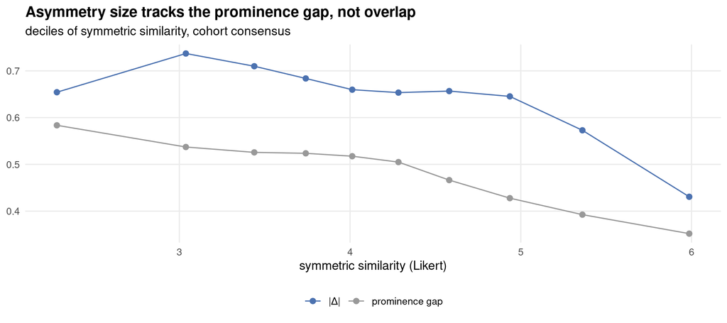

```r
tibble(s = s, ad = abs(d), gap = gap) %>%
  mutate(bin = ntile(s, 10)) %>% group_by(bin) %>%
  summarise(sim = mean(s), `|Δ|` = mean(ad), `prominence gap` = mean(gap), .groups="drop") %>%
  pivot_longer(c(`|Δ|`, `prominence gap`)) %>%
  ggplot(aes(sim, value, colour = name)) + geom_line() + geom_point(size = 2) +
  scale_colour_manual(values = c("#4C72B0", "grey60"), name = NULL) +
  labs(title = "Asymmetry size tracks the prominence gap, not overlap",
       subtitle = "deciles of symmetric similarity, cohort consensus",
       x = "symmetric similarity (Likert)", y = NULL) + theme_judge()
```

`|Δ|` correlates 0.62 with the prominence gap and **−0.01 with similarity once the gap is partialled** — the apparent decline of `|Δ|` at high similarity is entirely the gap shrinking. The additive-*f* contrast model is not rejected on its own terms; its failure is confined to the curl, which by construction it cannot produce at all.

## 5. The curl is diagnosticity — and it is far more reproducible than Report II implied

Report II correlated the curl **cell by cell** across raters (r̄ ≈ 0.34–0.40) and concluded it was “real but faint and idiosyncratic.” That is the wrong resolution for a context-dependence effect: diagnosticity shifts weights at the level of *categories*, so the shared part should be **low-rank**, and cell-level correlation charges it for all the per-cell noise. A skew-symmetric matrix has a natural low-rank structure — orthogonal **planes** of circulation (its SVD comes in pairs) — so the right question is whether the raters agree on the *planes*.

```r
svb <- svd(Cbar)
cum <- cumsum(svb$d^2)/sum(svb$d^2)
top_plane <- lapply(disc, function(m) svd(Cl[[m]])$u[,1:2]); names(top_plane) <- disc
subcong <- function(A, B) mean(svd(t(A) %*% B)$d)     # mean canonical correlation of subspaces
pc <- outer(seq_along(disc), seq_along(disc),
            Vectorize(function(a,b) subcong(top_plane[[a]], top_plane[[b]])))
set.seed(2)
pnull <- replicate(20, { pm <- sample(n); U <- svd(Cl[[disc[1]]][pm,pm])$u[,1:2]
                         mean(sapply(disc[-1], function(m) subcong(U, top_plane[[m]]))) })
cell <- cor(sapply(disc, function(m) Cl[[m]][ij]))
tibble(`Level of description` = c("individual cells (Report II)",
                                  "dominant curl plane (subspace congruence)",
                                  "  ...permuted-adjective null"),
       `agreement across the 10 raters` = round(c(mean(cell[upper.tri(cell)]),
                                                  mean(pc[upper.tri(pc)]), mean(pnull)), 3)) %>%
  knitr::kable(caption = "The curl's reproducibility depends entirely on the resolution you ask at.")
```

The curl’s reproducibility depends entirely on the resolution you ask at.

| Level of description | agreement across the 10 raters |
| --- | --- |
| individual cells (Report II) | 0.335 |
| dominant curl plane (subspace congruence) | 0.732 |
| …permuted-adjective null | 0.048 |

```r
cat(sprintf("Consensus curl: first plane = %.0f%% of curl variance, first three planes = %.0f%%.\n",
            100*cum[2], 100*cum[6]))
```

```
## Consensus curl: first plane = 47% of curl variance, first three planes = 65%.
```

**The dominant curl plane replicates at r̄ = 0.73 against a permutation null of 0.05.** The curl is not idiosyncratic — it is a *low-rank, strongly shared* directional structure that cell-wise correlation hid. It is also genuinely low-rank: one plane carries 47% of the consensus curl variance, three carry 65%.

```r
ax <- function(k, m = 10) { o <- order(-abs(svb$u[,k]))[1:m]
  paste0(ADJ[o], sprintf("(%+.2f)", svb$u[o,k]), collapse = ", ") }
tibble(Axis = c("plane-1, axis 1", "plane-1, axis 2"),
       `Highest-|loading| adjectives` = c(ax(1), ax(2))) %>%
  knitr::kable(caption = "What the dominant circulation plane is spanned by.")
```

What the dominant circulation plane is spanned by.

| Axis | Highest-\|loading\| adjectives |
| --- | --- |
| plane-1, axis 1 | pathetic(-0.10), valuable(+0.09), awesome(+0.09), lovable(+0.09), wonderful(+0.09), likeable(+0.09), senile(-0.09), good-for-nothing(-0.09), retarded(-0.08), respectable(+0.08) |
| plane-1, axis 2 | blind(+0.14), disabled(+0.14), handicapped(+0.13), evil(-0.13), abusive(-0.13), insane(-0.12), unattractive(+0.12), desirable(-0.12), short(+0.12), popular(-0.11) |

Axis 1 is the evaluative axis (*valuable, awesome, lovable, respectable* vs *pathetic, senile, good-for-nothing, retarded*). Axis 2 separates **misfortune** (*blind, disabled, handicapped, unattractive*) from **malevolence** (*evil, abusive, insane*) — two ways of being negatively valued that the models keep distinct and circulate between. That is a diagnosticity structure in the strict sense: which features get weight depends on which kind of “bad” the subject has put the person into.

Projecting the curl onto the five-factor basis from Report IV gives the construct-level picture:

```r
pca_load <- function(R, k) { e <- eigen(R, symmetric = TRUE)
  L <- e$vectors[,1:k,drop=FALSE] %*% diag(sqrt(pmax(e$values[1:k],0)), k)
  stats::varimax(L)$loadings[] }
L5 <- pca_load(Rcons, 5); W <- apply(L5, 2, function(v) v/sqrt(sum(v^2)))
flab <- c("F1 evaluative/competence","F2 antagonism","F3 negative affect",
          "F4 playful–uninhibited","F5 traditional–predictable")
Pm <- t(W) %*% Cbar %*% W; dimnames(Pm) <- list(flab, flab)
knitr::kable(round(Pm, 1),
  caption = "Consensus curl in the 5-factor basis. Row = subject, column = referent; positive = subject⇒referent endorsed more than the reverse, NET of prevalence.")
```

Consensus curl in the 5-factor basis. Row = subject, column = referent; positive = subject⇒referent endorsed more than the reverse, NET of prevalence.

|  | F1 evaluative/competence | F2 antagonism | F3 negative affect | F4 playful–uninhibited | F5 traditional–predictable |
| --- | --- | --- | --- | --- | --- |
| F1 evaluative/competence | 0.0 | -17.6 | -29.7 | -4.6 | 7.6 |
| F2 antagonism | 17.6 | 0.0 | -52.0 | -11.1 | 7.6 |
| F3 negative affect | 29.7 | 52.0 | 0.0 | -2.7 | -12.9 |
| F4 playful–uninhibited | 4.6 | 11.1 | 2.7 | 0.0 | -4.2 |
| F5 traditional–predictable | -7.6 | -7.6 | 12.9 | 4.2 | 0.0 |

```r
Pf <- sapply(disc, function(m) (t(W) %*% Cl[[m]] %*% W)[upper.tri(diag(5))])
set.seed(3)
nullf <- replicate(200, { R <- qr.Q(qr(matrix(rnorm(n*5), n, 5)))
  cc <- cor(sapply(disc, function(m) (t(R) %*% Cl[[m]] %*% R)[upper.tri(diag(5))]))
  mean(cc[upper.tri(cc)]) })
obs <- { cc <- cor(Pf); mean(cc[upper.tri(cc)]) }
cat(sprintf("cross-rater agreement of the 5x5 projected curl: r-bar = %.3f  (random-basis null %.3f, sd %.3f, p < %.3f)\n",
            obs, mean(nullf), sd(nullf), max(mean(nullf >= obs), 1/200)))
```

```
## cross-rater agreement of the 5x5 projected curl: r-bar = 0.716  (random-basis null 0.295, sd 0.149, p < 0.005)
```

```r
g5 <- rowMeans(Pm)
cat(sprintf("gradient share WITHIN the 5x5 curl: %.2f  — net source: %s\n",
            sum(outer(g5,g5,"-")^2)/sum(Pm^2), flab[which.max(g5)]))
```

```
## gradient share WITHIN the 5x5 curl: 0.37  — net source: F3 negative affect
```

At construct resolution the raters agree at **r̄ = 0.72** (random-basis null 0.30, p < 0.005). And the construct-level flow has a clear shape: **negative affect is the net source** — anchoring a person on F3 implies antagonism and low competence much more strongly than anchoring on antagonism or incompetence implies negative affect. A third of the 5×5 residual is itself a further additive potential, i.e. **after removing the adjective-level prominence gradient there is a second-order prominence ordering at the trait-factor level.**

One warning about reading examples off the curl. The curl is a *residual*, and for these pairs the prevalence gradient dominates the raw judgment, so the raw and residual directions can oppose:

```r
ex <- function(a,b){ ia<-match(a,ADJ); ib<-match(b,ADJ)
  tibble(pair = paste(a,"⇒",b), `raw Δ` = Dbar[ia,ib], `curl (residual) Δ` = Cbar[ia,ib]) }
bind_rows(ex("frustrated","rude"), ex("sad","hostile"), ex("anxious","critical")) %>%
  mutate(across(where(is.numeric), ~round(.,2))) %>%
  knitr::kable(caption = "Raw vs prevalence-free direction. Negative-affect words are highly prevalent referents, so the gradient masks the residual flow.")
```

Raw vs prevalence-free direction. Negative-affect words are highly prevalent referents, so the gradient masks the residual flow.

| pair | raw Δ | curl (residual) Δ |
| --- | --- | --- |
| frustrated ⇒ rude | -0.34 | 0.76 |
| sad ⇒ hostile | -1.05 | -0.11 |
| anxious ⇒ critical | -0.26 | -0.11 |

## 6. A metric-axiom check that comes out *negative* (usefully)

Tversky & Hutchinson (1986) give the sharpest test of whether a proximity structure can be a *space* at all: in Euclidean *d*-space the number of points that can share one nearest neighbour is bounded (2 in 1-D, 5 in 2-D, 11 in 3-D). Perceptual data respect the bound; conceptual/taxonomic data routinely blow through it, because feature structures have focal points that spatial models cannot host. If the trait lexicon were feature-like in that sense, embedding it — which everything downstream, including rgb’s geometric track, does — would be lossy in a specific diagnosable way.

```r
nnC <- function(M) { diag(M) <- -Inf; N <- tabulate(apply(M, 1, which.max), nbins = n)
  c(C = sum(N^2)/n, maxN = max(N)) }
raw <- nnC(Sbar); dc <- nnC(double_center(Sbar))
Sd <- Sbar; diag(Sd) <- -Inf; Ni <- tabulate(apply(Sd, 1, which.max), nbins = n)
o <- order(-Ni)
cat(sprintf("consensus symmetric: C = %.2f, max N_i = %d   |   double-centered: C = %.2f, max N_i = %d\n",
            raw["C"], raw["maxN"], dc["C"], dc["maxN"]))
```

```
## consensus symmetric: C = 2.31, max N_i = 9   |   double-centered: C = 3.10, max N_i = 15
```

```r
cat("top nearest-neighbour attractors:",
    paste0(ADJ[o[1:10]], "(", Ni[o[1:10]], ")", collapse = ", "), "\n\n")
```

```
## top nearest-neighbour attractors: kind(9), self-centered(6), thinking(6), awesome(5), loving(5), useful(5), determined(4), egotistical(4), enthusiastic(4), kind-hearted(4)
```

```r
knitr::kable(tibble(Model = DISPLAY[MODELS],
  C = round(sapply(MODELS, function(m) nnC(Sl[[m]])["C"]), 2),
  `max N_i` = sapply(MODELS, function(m) nnC(Sl[[m]])["maxN"])) %>% arrange(desc(C)),
  caption = "Nearest-neighbour centrality per rater.")
```

Nearest-neighbour centrality per rater.

| Model | C | max N_i |
| --- | --- | --- |
| Qwen2.5-7B | 9.49 | 58 |
| Llama3.2-3B | 8.29 | 24 |
| Llama3.1-8B | 4.14 | 14 |
| Gemma3-4B | 3.43 | 16 |
| Gemma3-12B | 3.39 | 18 |
| FalconMamba-7B | 3.33 | 11 |
| Phi4-mini-3.8B | 3.20 | 14 |
| Aya-expanse-8B | 2.57 | 9 |
| Gemma-4-31B | 2.49 | 15 |
| Gemma3-27B | 2.46 | 9 |
| Qwen2.5-3B | 2.43 | 9 |
| Qwen2.5-32B | 2.22 | 7 |

**No focal-point violation.** `max N_i = 9` needs only three Euclidean dimensions, and C = 2.31 is unremarkable. The *symmetric* JUDGE similarity is comfortably spatial — a point in favour of the geometric treatments, and an honest negative result for the “features not space” story: **JUDGE is non-metric in its asymmetry (§1–§5), not in its symmetric part.** The two raters with anomalous centrality (`Qwen2.5-7B` 9.5, `Llama3.2-3B` 8.3) are the range-restricted ones — this is a rater-quality signal, not a construct one, and it is a cheap new diagnostic for flat raters.

## 7. The contrast weight is a rater property

Scale-free per-rater measures of how strongly the subject-role dominates: the spread of the recovered potential relative to the rater’s own judgment spread.

```r
map_dfr(MODELS, function(m) { S <- Sl[[m]]; diag(S) <- NA; off <- !is.na(S)
  tibble(Model = DISPLAY[m], Family = FAMILY[m],
         `SD of ratings` = sd(S[off]),
         `asymmetry weight  sd(g)/sd(B)` = sd(Gm[,m])/sd(S[off]),
         `separable share` = sep[m],
         `corr(f, symmetric marginal)` = cor(-Gm[,m], rowMeans(S, na.rm = TRUE))) }) %>%
  mutate(across(where(is.numeric), ~round(.,3))) %>% arrange(desc(`asymmetry weight  sd(g)/sd(B)`)) %>%
  knitr::kable(caption = "Contrast-model parameters as per-rater properties.")
```

Contrast-model parameters as per-rater properties.

| Model | Family | SD of ratings | asymmetry weight sd(g)/sd(B) | separable share | corr(f, symmetric marginal) |
| --- | --- | --- | --- | --- | --- |
| Llama3.2-3B | Llama | 0.402 | 0.636 | 0.615 | 0.008 |
| Gemma3-4B | Gemma | 1.252 | 0.588 | 0.485 | 0.362 |
| Qwen2.5-32B | Qwen | 0.957 | 0.566 | 0.528 | 0.836 |
| Llama3.1-8B | Llama | 0.913 | 0.538 | 0.569 | 0.517 |
| Phi4-mini-3.8B | Phi | 1.561 | 0.522 | 0.637 | 0.726 |
| Qwen2.5-3B | Qwen | 1.463 | 0.516 | 0.520 | 0.318 |
| Aya-expanse-8B | Aya | 1.698 | 0.511 | 0.418 | 0.163 |
| Qwen2.5-7B | Qwen | 1.014 | 0.505 | 0.500 | 0.728 |
| Gemma3-12B | Gemma | 1.074 | 0.476 | 0.411 | 0.555 |
| Gemma-4-31B | Gemma | 0.866 | 0.472 | 0.358 | 0.831 |
| Gemma3-27B | Gemma | 1.264 | 0.454 | 0.463 | 0.744 |
| FalconMamba-7B | Falcon | 0.705 | 0.364 | 0.543 | 0.323 |

The asymmetry weight varies ~1.7× (0.36–0.64) and is **not** a size or family effect. The last column is a genuine over-identification test: the contrast model says the *same* *f* governs the asymmetry and the symmetric marginal, so the correlation should be strongly positive. It is, for the larger and more differentiated raters (`Qwen2.5-32B` 0.84, `Gemma-4-31B` 0.83, `Qwen2.5-7B`/`Phi4` 0.73) — and it **collapses to ~0 for `Llama3.2-3B` (0.01) and `Aya` (0.16)**. For those raters the directional signal and the similarity signal do not share a prominence scale, i.e. the contrast model does not hold of them at all. That is a useful, theory-derived rater-fit statistic, and it agrees with the response-style verdicts from Report I rather than duplicating them.

## 8. What we cannot identify, and the right experiment for it

The one contrast-model quantity the collected data cannot deliver is the split between **α and β separately** — we identify only `(β − α)f` from the skew part and `−((α+β)/2)f + θc̄` from the symmetric marginal, which is one equation short because θ and the mean commonality `c̄` are entangled with it. Everything in §1–§7 is a statement about `(β − α)f` and about the shape of the residual; the *focusing* weight itself is not estimated.

### 8.1 Why the diagonal is the wrong instrument for it

Tversky’s own identification is the **diagonal**: `s(a,a) = θ f(A)`, since the distinctive sets are empty. rgb’s `dists` tensor has a NaN diagonal — the 523 self-pairs were never collected — so this looks like a cheap fix. It is not, for three reasons, and the third is decisive.

**(a) The self-pair task is pragmatically degenerate.** “Consider a person who is very *kind*. How likely is this person to *also* be *kind*?” — *also* presupposes a distinct second predicate, so the question is ill-formed. Any variance returned is variance in how a model handles an ill-formed question. Worse, a model that resolves the anomaly by reading *also* as “additionally, over and above being kind” is answering a **different question** than it answers off-diagonal, in which case the diagonal is not on the same scale as the matrix it was supposed to anchor.

**(b) The operationalization does not transfer.** Tversky did not obtain `s(a,a)` by asking how similar a thing is to itself. He read it off **identification/confusion** data — Rothkopf’s Morse-code matrix, letter-confusion matrices — where `p(a → a)` falls out of a task that is perfectly well-formed. JUDGE has no confusion task, so the psychometric move has no vehicle here.

**(c) Ceiling — the decisive one.** Substituting each adjective’s best available near-synonym for literal identity (distinctive sets near-empty, so `s ≈ θf(A)`) shows where the diagonal would land:

```r
Sd <- Sbar; diag(Sd) <- NA
ceil <- apply(Sd, 1, max, na.rm = TRUE)
nb   <- apply(Sd, 1, function(r) which.max(replace(r, is.na(r), -Inf)))
cat(sprintf("near-identity ceiling max_j S[i,j]: mean %.2f, sd %.2f, range %.2f-%.2f\n",
            mean(ceil), sd(ceil), min(ceil), max(ceil)))
```

```
## near-identity ceiling max_j S[i,j]: mean 6.49, sd 0.40, range 4.38-6.97
```

```r
cat(sprintf("  fraction already >= 6.5: %.0f%%   |   >= 6.9: %.0f%%   (scale max = 7)\n",
            100*mean(ceil >= 6.5), 100*mean(ceil >= 6.9)))
```

```
##   fraction already >= 6.5: 58%   |   >= 6.9: 11%   (scale max = 7)
```

```r
cat(sprintf("  correlation with the recovered prominence f: %.2f\n", cor(ceil, fbar)))
```

```
##   correlation with the recovered prominence f: 0.46
```

```r
bind_rows(
  tibble(End = "lowest ceiling",  i = order(ceil)[1:6]),
  tibble(End = "highest ceiling", i = order(-ceil)[1:6])) %>%
  transmute(End, Adjective = ADJ[i], `ceiling` = round(ceil[i], 2),
            `best available near-synonym` = ADJ[nb[i]]) %>%
  knitr::kable(caption = "Where a self-pair would land: the near-identity ceiling.")
```

Where a self-pair would land: the near-identity ceiling.

| End | Adjective | ceiling | best available near-synonym |
| --- | --- | --- | --- |
| lowest ceiling | retarded | 4.38 | dumb |
| lowest ceiling | blind | 4.73 | elderly |
| lowest ceiling | unattractive | 4.93 | normal |
| lowest ceiling | plain | 5.20 | thinking |
| lowest ceiling | left-handed | 5.21 | awake |
| lowest ceiling | unlucky | 5.23 | thinking |
| highest ceiling | enthusiastic | 6.97 | excited |
| highest ceiling | excited | 6.97 | enthusiastic |
| highest ceiling | grateful | 6.97 | thankful |
| highest ceiling | thankful | 6.97 | grateful |
| highest ceiling | sociable | 6.96 | social |
| highest ceiling | social | 6.96 | sociable |

**58% of adjectives already sit at ≥ 6.5 and 11% at ≥ 6.9 on a 7-point scale.** The literal self-pair would be a wall of 7s for the large majority, leaving almost no variance to read `f` from — and `f` has to span the distance between *thinking* and *blind* to be worth anything. The near-synonym proxy does not rescue it either: it correlates only 0.46 with `f`, and the low-ceiling cases are low because the 523-word set happens to contain no synonym for them (*retarded*, *blind*, *left-handed*), which is a **coverage artefact of the item pool**, not low self-similarity.

**What the diagonal *is* worth** is a smaller and honest claim: an **instrument-integrity check**. A rater that answers 5 rather than 7 to “very kind ⇒ kind” is reading a contrast presupposition into *also* — which would mean every off-diagonal cell means something other than what this whole track has assumed. Ruling that out is worth 523 cheap prompts. It would also calibrate each rater’s true ceiling — `FalconMamba` and `Llama3.2-3B` never exceed 6.25 and 6.03 *anywhere* in the matrix, so their compression is currently confounded with their content. Useful; not an identification of α and β.

### 8.2 The right experiment: the dissimilarity frame

Tversky’s own lever for separating the weights is to ask for **difference** rather than similarity. The same features are available, but the weights on the *distinctive* sets change, and the asymmetry can **reverse**. That is the manipulation to run, and it adjudicates §3’s deflationary rival in a way the diagonal never could:

> *Consider a person who is very **{i}**. How **unlike** a person who is very **{j}** are they?*
- A **base-rate** account (`B[i,j] ≈ P(j | i)`) predicts **no reversal**: conditional probability does not flip sign when the question is rephrased toward difference.
- The **contrast model** predicts the prominence gradient **inverts**.

The task is well-formed, so neither failure mode in §8.1 applies. It does not need the full 273,006 cells: sampling a few thousand pairs at **high prominence gap** — where §2 shows the directional effect is 97% consistent and therefore where the test has power — is enough, plus a matched low-gap control block. Running the **symmetric** frame (“how similar are a person who is very *i* and a person who is very *j*?”) on the same pairs adds the α = β condition and pins the focusing effect by manipulation rather than by assumption.

Four cohort models (`gemma3:4b`, `qwen2.5:3b`, `llama3.2:3b`, `phi4-mini`) are in the Orin lineup, so a 4-model × 3-frame design over a few thousand pairs is a modest one-off run — and it is the same referent-swap logic the readout account already budgets for, applied to the one place where the two theories make opposite predictions.

## Verdict — and two amendments to Report II

Tversky’s contrast model is not a loose analogy for JUDGE; it is a **fitted model that explains half the directional variance with one parameter per adjective** and correctly predicts the direction of the asymmetry across essentially the whole item set. Two things in Report II should be revised.

**Amendment 1 — the gradient is not “the trivial Bayes direction.”** It is the contrast model’s prominence term, and prominence is *not* a base rate: net of a flexible spline in prevalence it carries a large, universally-signed **negativity** component (undesirable traits are stronger referents) and no lexical-frequency component. Double-centering still removes it, correctly, for the similarity measurement — but it removes a **construct** (the models’ feature-salience ordering over the trait lexicon), not an artefact, and that construct is worth reporting in its own right.

**Amendment 2 — the curl is not “faint and idiosyncratic.”** At the resolution the theory predicts it should live at, it is **low-rank and strongly shared**: dominant-plane congruence 0.73 (null 0.05), construct-level agreement 0.72 (null 0.30). Report II’s r̄ = 0.34 measured cell-level noise, not the structure. The curl is a legitimate, reproducible **diagnosticity** channel with an interpretable shape — an evaluative × (misfortune vs malevolence) circulation, with negative affect as the construct-level net source.

The *measurement* verdict is unchanged: symmetrize for the similarity. What changes is the status of what we set aside. It is a second construct with its own reliability, its own theory, and — for the readout account — its own model-level parameters (§7), and it should be carried as such rather than filed as nuisance.